# Risk Factor Analysis

## Outcome Variable

**Outcome Variable:** wasted

## Predictor Variables

**Intervention Variable:** mage

**Adjustment Set:**

unadjusted

## Stratifying Variables

The analysis was stratified on these variable(s):

- agecat
- studyid
- country

## Data Summary

| agecat | studyid | country | mage | wasted | n_cell | n |
| --- | --- | --- | --- | --- | --- | --- |
| Birth | ki0047075b-MAL-ED | BANGLADESH | <25 | 0 | 91 | 241 |
| Birth | ki0047075b-MAL-ED | BANGLADESH | <25 | 1 | 18 | 241 |
| Birth | ki0047075b-MAL-ED | BANGLADESH | [25-30) | 0 | 76 | 241 |
| Birth | ki0047075b-MAL-ED | BANGLADESH | [25-30) | 1 | 13 | 241 |
| Birth | ki0047075b-MAL-ED | BANGLADESH | >=30 | 0 | 34 | 241 |
| Birth | ki0047075b-MAL-ED | BANGLADESH | >=30 | 1 | 9 | 241 |
| Birth | ki0047075b-MAL-ED | BRAZIL | <25 | 0 | 93 | 183 |
| Birth | ki0047075b-MAL-ED | BRAZIL | <25 | 1 | 1 | 183 |
| Birth | ki0047075b-MAL-ED | BRAZIL | [25-30) | 0 | 47 | 183 |
| Birth | ki0047075b-MAL-ED | BRAZIL | [25-30) | 1 | 3 | 183 |
| Birth | ki0047075b-MAL-ED | BRAZIL | >=30 | 0 | 37 | 183 |
| Birth | ki0047075b-MAL-ED | BRAZIL | >=30 | 1 | 2 | 183 |
| Birth | ki0047075b-MAL-ED | INDIA | <25 | 0 | 100 | 202 |
| Birth | ki0047075b-MAL-ED | INDIA | <25 | 1 | 20 | 202 |
| Birth | ki0047075b-MAL-ED | INDIA | [25-30) | 0 | 56 | 202 |
| Birth | ki0047075b-MAL-ED | INDIA | [25-30) | 1 | 11 | 202 |
| Birth | ki0047075b-MAL-ED | INDIA | >=30 | 0 | 13 | 202 |
| Birth | ki0047075b-MAL-ED | INDIA | >=30 | 1 | 2 | 202 |
| Birth | ki0047075b-MAL-ED | NEPAL | <25 | 0 | 35 | 168 |
| Birth | ki0047075b-MAL-ED | NEPAL | <25 | 1 | 8 | 168 |
| Birth | ki0047075b-MAL-ED | NEPAL | [25-30) | 0 | 81 | 168 |
| Birth | ki0047075b-MAL-ED | NEPAL | [25-30) | 1 | 9 | 168 |
| Birth | ki0047075b-MAL-ED | NEPAL | >=30 | 0 | 32 | 168 |
| Birth | ki0047075b-MAL-ED | NEPAL | >=30 | 1 | 3 | 168 |
| Birth | ki0047075b-MAL-ED | PERU | <25 | 0 | 152 | 279 |
| Birth | ki0047075b-MAL-ED | PERU | <25 | 1 | 3 | 279 |
| Birth | ki0047075b-MAL-ED | PERU | [25-30) | 0 | 58 | 279 |
| Birth | ki0047075b-MAL-ED | PERU | [25-30) | 1 | 2 | 279 |
| Birth | ki0047075b-MAL-ED | PERU | >=30 | 0 | 63 | 279 |
| Birth | ki0047075b-MAL-ED | PERU | >=30 | 1 | 1 | 279 |

[output cut: 378 more lines]

The following strata were considered:

- agecat: 24 months, studyid: ki0047075b-MAL-ED, country: BANGLADESH
- agecat: 24 months, studyid: ki0047075b-MAL-ED, country: BRAZIL
- agecat: 24 months, studyid: ki0047075b-MAL-ED, country: INDIA
- agecat: 24 months, studyid: ki0047075b-MAL-ED, country: NEPAL
- agecat: 24 months, studyid: ki0047075b-MAL-ED, country: PERU
- agecat: 24 months, studyid: ki0047075b-MAL-ED, country: SOUTH AFRICA
- agecat: 24 months, studyid: ki0047075b-MAL-ED, country: TANZANIA, UNITED REPUBLIC OF
- agecat: 24 months, studyid: ki1000108-CMC-V-BCS-2002, country: INDIA
- agecat: 24 months, studyid: ki1000108-IRC, country: INDIA
- agecat: 24 months, studyid: ki1017093-NIH-Birth, country: BANGLADESH
- agecat: 24 months, studyid: ki1017093b-PROVIDE, country: BANGLADESH
- agecat: 24 months, studyid: ki1017093c-NIH-Crypto, country: BANGLADESH
- agecat: 24 months, studyid: ki1066203-TanzaniaChild2, country: TANZANIA, UNITED REPUBLIC OF
- agecat: 24 months, studyid: ki1101329-Keneba, country: GAMBIA
- agecat: 24 months, studyid: ki1113344-GMS-Nepal, country: NEPAL
- agecat: 24 months, studyid: ki1119695-PROBIT, country: BELARUS
- agecat: 24 months, studyid: ki1126311-ZVITAMBO, country: ZIMBABWE
- agecat: 24 months, studyid: ki1135781-COHORTS, country: GUATEMALA
- agecat: 24 months, studyid: ki1135781-COHORTS, country: INDIA
- agecat: 24 months, studyid: ki1135781-COHORTS, country: PHILIPPINES
- agecat: 24 months, studyid: ki1148112-LCNI-5, country: MALAWI
- agecat: 24 months, studyid: kiGH5241-JiVitA-3, country: BANGLADESH
- agecat: 6 months, studyid: ki0047075b-MAL-ED, country: BANGLADESH
- agecat: 6 months, studyid: ki0047075b-MAL-ED, country: BRAZIL
- agecat: 6 months, studyid: ki0047075b-MAL-ED, country: INDIA
- agecat: 6 months, studyid: ki0047075b-MAL-ED, country: NEPAL
- agecat: 6 months, studyid: ki0047075b-MAL-ED, country: PERU
- agecat: 6 months, studyid: ki0047075b-MAL-ED, country: SOUTH AFRICA
- agecat: 6 months, studyid: ki0047075b-MAL-ED, country: TANZANIA, UNITED REPUBLIC OF
- agecat: 6 months, studyid: ki1000108-CMC-V-BCS-2002, country: INDIA
- agecat: 6 months, studyid: ki1000108-IRC, country: INDIA
- agecat: 6 months, studyid: ki1000109-EE, country: PAKISTAN
- agecat: 6 months, studyid: ki1000304b-SAS-CompFeed, country: INDIA
- agecat: 6 months, studyid: ki1000304b-SAS-FoodSuppl, country: INDIA
- agecat: 6 months, studyid: ki1017093-NIH-Birth, country: BANGLADESH
- agecat: 6 months, studyid: ki1017093b-PROVIDE, country: BANGLADESH
- agecat: 6 months, studyid: ki1017093c-NIH-Crypto, country: BANGLADESH
- agecat: 6 months, studyid: ki1066203-TanzaniaChild2, country: TANZANIA, UNITED REPUBLIC OF
- agecat: 6 months, studyid: ki1101329-Keneba, country: GAMBIA
- agecat: 6 months, studyid: ki1112895-Guatemala BSC, country: GUATEMALA
- agecat: 6 months, studyid: ki1113344-GMS-Nepal, country: NEPAL
- agecat: 6 months, studyid: ki1119695-PROBIT, country: BELARUS
- agecat: 6 months, studyid: ki1126311-ZVITAMBO, country: ZIMBABWE
- agecat: 6 months, studyid: ki1135781-COHORTS, country: GUATEMALA
- agecat: 6 months, studyid: ki1135781-COHORTS, country: INDIA
- agecat: 6 months, studyid: ki1135781-COHORTS, country: PHILIPPINES
- agecat: 6 months, studyid: ki1148112-LCNI-5, country: MALAWI
- agecat: 6 months, studyid: kiGH5241-JiVitA-3, country: BANGLADESH
- agecat: Birth, studyid: ki0047075b-MAL-ED, country: BANGLADESH
- agecat: Birth, studyid: ki0047075b-MAL-ED, country: BRAZIL
- agecat: Birth, studyid: ki0047075b-MAL-ED, country: INDIA
- agecat: Birth, studyid: ki0047075b-MAL-ED, country: NEPAL
- agecat: Birth, studyid: ki0047075b-MAL-ED, country: PERU
- agecat: Birth, studyid: ki0047075b-MAL-ED, country: SOUTH AFRICA
- agecat: Birth, studyid: ki0047075b-MAL-ED, country: TANZANIA, UNITED REPUBLIC OF
- agecat: Birth, studyid: ki1000108-CMC-V-BCS-2002, country: INDIA
- agecat: Birth, studyid: ki1000108-IRC, country: INDIA
- agecat: Birth, studyid: ki1000109-EE, country: PAKISTAN
- agecat: Birth, studyid: ki1000304b-SAS-CompFeed, country: INDIA
- agecat: Birth, studyid: ki1017093-NIH-Birth, country: BANGLADESH
- agecat: Birth, studyid: ki1017093c-NIH-Crypto, country: BANGLADESH
- agecat: Birth, studyid: ki1101329-Keneba, country: GAMBIA
- agecat: Birth, studyid: ki1119695-PROBIT, country: BELARUS
- agecat: Birth, studyid: ki1126311-ZVITAMBO, country: ZIMBABWE
- agecat: Birth, studyid: ki1135781-COHORTS, country: GUATEMALA
- agecat: Birth, studyid: ki1135781-COHORTS, country: INDIA
- agecat: Birth, studyid: ki1135781-COHORTS, country: PHILIPPINES
- agecat: Birth, studyid: kiGH5241-JiVitA-3, country: BANGLADESH

### Dropped Strata

Some strata were dropped due to rare outcomes:

- agecat: Birth, studyid: ki0047075b-MAL-ED, country: BRAZIL
- agecat: Birth, studyid: ki0047075b-MAL-ED, country: INDIA
- agecat: Birth, studyid: ki0047075b-MAL-ED, country: NEPAL
- agecat: Birth, studyid: ki0047075b-MAL-ED, country: PERU
- agecat: Birth, studyid: ki0047075b-MAL-ED, country: SOUTH AFRICA
- agecat: Birth, studyid: ki0047075b-MAL-ED, country: TANZANIA, UNITED REPUBLIC OF
- agecat: Birth, studyid: ki1000108-CMC-V-BCS-2002, country: INDIA
- agecat: Birth, studyid: ki1000109-EE, country: PAKISTAN
- agecat: Birth, studyid: ki1000304b-SAS-CompFeed, country: INDIA
- agecat: Birth, studyid: ki1017093-NIH-Birth, country: BANGLADESH
- agecat: Birth, studyid: ki1017093c-NIH-Crypto, country: BANGLADESH
- agecat: 6 months, studyid: ki0047075b-MAL-ED, country: BANGLADESH
- agecat: 6 months, studyid: ki0047075b-MAL-ED, country: BRAZIL
- agecat: 6 months, studyid: ki0047075b-MAL-ED, country: INDIA
- agecat: 6 months, studyid: ki0047075b-MAL-ED, country: NEPAL
- agecat: 6 months, studyid: ki0047075b-MAL-ED, country: PERU
- agecat: 6 months, studyid: ki0047075b-MAL-ED, country: SOUTH AFRICA
- agecat: 6 months, studyid: ki0047075b-MAL-ED, country: TANZANIA, UNITED REPUBLIC OF
- agecat: 6 months, studyid: ki1000108-CMC-V-BCS-2002, country: INDIA
- agecat: 6 months, studyid: ki1000109-EE, country: PAKISTAN
- agecat: 6 months, studyid: ki1017093c-NIH-Crypto, country: BANGLADESH
- agecat: 6 months, studyid: ki1112895-Guatemala BSC, country: GUATEMALA
- agecat: 6 months, studyid: ki1148112-LCNI-5, country: MALAWI
- agecat: 24 months, studyid: ki0047075b-MAL-ED, country: BANGLADESH
- agecat: 24 months, studyid: ki0047075b-MAL-ED, country: BRAZIL
- agecat: 24 months, studyid: ki0047075b-MAL-ED, country: INDIA
- agecat: 24 months, studyid: ki0047075b-MAL-ED, country: NEPAL
- agecat: 24 months, studyid: ki0047075b-MAL-ED, country: PERU
- agecat: 24 months, studyid: ki0047075b-MAL-ED, country: SOUTH AFRICA
- agecat: 24 months, studyid: ki0047075b-MAL-ED, country: TANZANIA, UNITED REPUBLIC OF
- agecat: 24 months, studyid: ki1000108-CMC-V-BCS-2002, country: INDIA
- agecat: 24 months, studyid: ki1066203-TanzaniaChild2, country: TANZANIA, UNITED REPUBLIC OF
- agecat: 24 months, studyid: ki1148112-LCNI-5, country: MALAWI

## Methods Detail

We’re interested in the causal parameters $E[Y_a]$ for all values of $a \in \mathcal{A}$. These parameters represent the mean outcome if, possibly contrary to fact, we intervened to set all units to have $A=a$. Under the randomization and positivity assumptions, these are identified by the statistical parameters $\psi_a=E_W[E_{Y|A,W}(Y|A=a,W)]$. In addition, we’re interested in the mean of $Y$, $E[Y]$ under no intervention (the observed mean). We will estimate these parameters by using SuperLearner to fit the relevant likelihood factors – $E_{Y|A,W}(Y|A=a,W)$ and $p(A=a|W)$, and then updating our likelihood fit using a joint TMLE.

For unadjusted analyses ($W=\{\}$), initial likelihoods were estimated using Lrnr_glm to estimate the simple $E(Y|A)$ and Lrnr_mean to estimate $p(A)$. For adjusted analyses, a small library containing Lrnr_glmnet, Lrnr_xgboost, and Lrnr_mean was used.

Having estimated these parameters, we will then use the delta method to estimate relative risks and attributable risks relative to a prespecified baseline level of $A$.

# Results Detail

## Results Plots

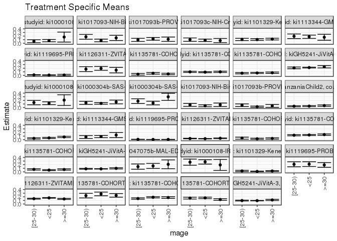

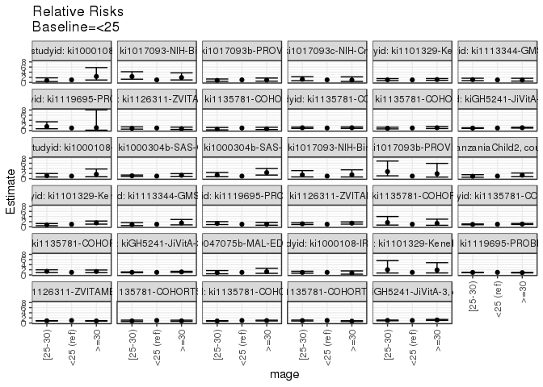

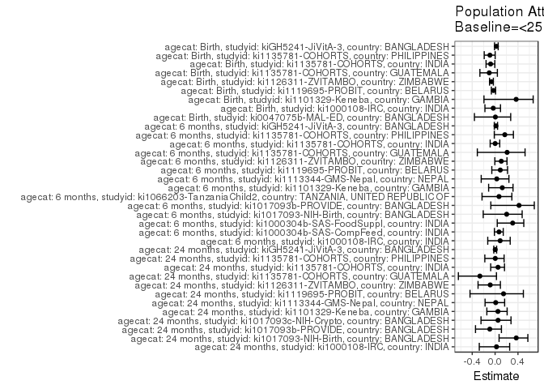

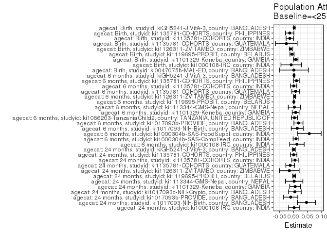

## Results Table

### Parameter: TSM

| agecat | studyid | country | intervention_level | baseline_level | estimate | ci_lower | ci_upper |
| --- | --- | --- | --- | --- | --- | --- | --- |
| Birth | ki0047075b-MAL-ED | BANGLADESH | <25 | NA | 0.1651376 | 0.0952873 | 0.2349879 |
| Birth | ki0047075b-MAL-ED | BANGLADESH | [25-30) | NA | 0.1460674 | 0.0725408 | 0.2195940 |
| Birth | ki0047075b-MAL-ED | BANGLADESH | >=30 | NA | 0.2093023 | 0.0874570 | 0.3311477 |
| Birth | ki1000108-IRC | INDIA | <25 | NA | 0.2769953 | 0.2168088 | 0.3371818 |
| Birth | ki1000108-IRC | INDIA | [25-30) | NA | 0.2692308 | 0.1838583 | 0.3546032 |
| Birth | ki1000108-IRC | INDIA | >=30 | NA | 0.1923077 | 0.0405968 | 0.3440186 |
| Birth | ki1101329-Keneba | GAMBIA | <25 | NA | 0.0124334 | 0.0032770 | 0.0215898 |
| Birth | ki1101329-Keneba | GAMBIA | [25-30) | NA | 0.0252366 | 0.0079649 | 0.0425083 |
| Birth | ki1101329-Keneba | GAMBIA | >=30 | NA | 0.0239411 | 0.0110790 | 0.0368031 |
| Birth | ki1119695-PROBIT | BELARUS | <25 | NA | 0.2146801 | 0.1495432 | 0.2798170 |
| Birth | ki1119695-PROBIT | BELARUS | [25-30) | NA | 0.2091942 | 0.1398297 | 0.2785587 |
| Birth | ki1119695-PROBIT | BELARUS | >=30 | NA | 0.1915315 | 0.1260461 | 0.2570168 |
| Birth | ki1126311-ZVITAMBO | ZIMBABWE | <25 | NA | 0.1693355 | 0.1608438 | 0.1778272 |
| Birth | ki1126311-ZVITAMBO | ZIMBABWE | [25-30) | NA | 0.1483670 | 0.1360794 | 0.1606547 |
| Birth | ki1126311-ZVITAMBO | ZIMBABWE | >=30 | NA | 0.1404883 | 0.1258705 | 0.1551060 |
| Birth | ki1135781-COHORTS | GUATEMALA | <25 | NA | 0.2800000 | 0.2291583 | 0.3308417 |
| Birth | ki1135781-COHORTS | GUATEMALA | [25-30) | NA | 0.2321429 | 0.1682579 | 0.2960278 |
| Birth | ki1135781-COHORTS | GUATEMALA | >=30 | NA | 0.2395833 | 0.1902553 | 0.2889113 |
| Birth | ki1135781-COHORTS | INDIA | <25 | NA | 0.1870933 | 0.1692914 | 0.2048952 |
| Birth | ki1135781-COHORTS | INDIA | [25-30) | NA | 0.1515775 | 0.1331680 | 0.1699870 |
| Birth | ki1135781-COHORTS | INDIA | >=30 | NA | 0.1795104 | 0.1568592 | 0.2021616 |
| Birth | ki1135781-COHORTS | PHILIPPINES | <25 | NA | 0.1696498 | 0.1491250 | 0.1901746 |
| Birth | ki1135781-COHORTS | PHILIPPINES | [25-30) | NA | 0.1635916 | 0.1381604 | 0.1890229 |
| Birth | ki1135781-COHORTS | PHILIPPINES | >=30 | NA | 0.1248439 | 0.1019493 | 0.1477386 |
| Birth | kiGH5241-JiVitA-3 | BANGLADESH | <25 | NA | 0.0937005 | 0.0878137 | 0.0995873 |
| Birth | kiGH5241-JiVitA-3 | BANGLADESH | [25-30) | NA | 0.0956429 | 0.0835353 | 0.1077505 |
| Birth | kiGH5241-JiVitA-3 | BANGLADESH | >=30 | NA | 0.1123596 | 0.0956035 | 0.1291156 |
| 6 months | ki1000108-IRC | INDIA | <25 | NA | 0.1206226 | 0.0807553 | 0.1604898 |
| 6 months | ki1000108-IRC | INDIA | [25-30) | NA | 0.1393443 | 0.0778180 | 0.2008705 |
| 6 months | ki1000108-IRC | INDIA | >=30 | NA | 0.2068966 | 0.0592839 | 0.3545092 |

[output cut: 75 more lines]

### Parameter: E(Y)

| agecat | studyid | country | intervention_level | baseline_level | estimate | ci_lower | ci_upper |
| --- | --- | --- | --- | --- | --- | --- | --- |
| Birth | ki0047075b-MAL-ED | BANGLADESH | NA | NA | 0.1659751 | 0.1189041 | 0.2130461 |
| Birth | ki1000108-IRC | INDIA | NA | NA | 0.2682216 | 0.2212677 | 0.3151755 |
| Birth | ki1101329-Keneba | GAMBIA | NA | NA | 0.0196767 | 0.0124580 | 0.0268954 |
| Birth | ki1119695-PROBIT | BELARUS | NA | NA | 0.2089120 | 0.1435514 | 0.2742726 |
| Birth | ki1126311-ZVITAMBO | ZIMBABWE | NA | NA | 0.1592391 | 0.1529198 | 0.1655584 |
| Birth | ki1135781-COHORTS | GUATEMALA | NA | NA | 0.2539683 | 0.2229196 | 0.2850169 |
| Birth | ki1135781-COHORTS | INDIA | NA | NA | 0.1734393 | 0.1622569 | 0.1846217 |
| Birth | ki1135781-COHORTS | PHILIPPINES | NA | NA | 0.1555709 | 0.1423748 | 0.1687670 |
| Birth | kiGH5241-JiVitA-3 | BANGLADESH | NA | NA | 0.0958477 | 0.0906460 | 0.1010493 |
| 6 months | ki1000108-IRC | INDIA | NA | NA | 0.1323529 | 0.0994307 | 0.1652752 |
| 6 months | ki1000304b-SAS-CompFeed | INDIA | NA | NA | 0.1244378 | 0.0992652 | 0.1496104 |
| 6 months | ki1000304b-SAS-FoodSuppl | INDIA | NA | NA | 0.1815789 | 0.1427684 | 0.2203895 |
| 6 months | ki1017093-NIH-Birth | BANGLADESH | NA | NA | 0.0636704 | 0.0429419 | 0.0843989 |
| 6 months | ki1017093b-PROVIDE | BANGLADESH | NA | NA | 0.0412371 | 0.0250690 | 0.0574052 |
| 6 months | ki1066203-TanzaniaChild2 | TANZANIA, UNITED REPUBLIC OF | NA | NA | 0.0432621 | 0.0343680 | 0.0521561 |
| 6 months | ki1101329-Keneba | GAMBIA | NA | NA | 0.0576923 | 0.0476698 | 0.0677148 |
| 6 months | ki1113344-GMS-Nepal | NEPAL | NA | NA | 0.0905861 | 0.0668565 | 0.1143158 |
| 6 months | ki1119695-PROBIT | BELARUS | NA | NA | 0.0082503 | 0.0066012 | 0.0098994 |
| 6 months | ki1126311-ZVITAMBO | ZIMBABWE | NA | NA | 0.0321251 | 0.0283197 | 0.0359306 |
| 6 months | ki1135781-COHORTS | GUATEMALA | NA | NA | 0.0332295 | 0.0219033 | 0.0445557 |
| 6 months | ki1135781-COHORTS | INDIA | NA | NA | 0.1321217 | 0.1226366 | 0.1416069 |
| 6 months | ki1135781-COHORTS | PHILIPPINES | NA | NA | 0.0594974 | 0.0505830 | 0.0684118 |
| 6 months | kiGH5241-JiVitA-3 | BANGLADESH | NA | NA | 0.0846892 | 0.0798858 | 0.0894926 |
| 24 months | ki1000108-IRC | INDIA | NA | NA | 0.0757946 | 0.0501131 | 0.1014762 |
| 24 months | ki1017093-NIH-Birth | BANGLADESH | NA | NA | 0.1244131 | 0.0930343 | 0.1557919 |
| 24 months | ki1017093b-PROVIDE | BANGLADESH | NA | NA | 0.1124567 | 0.0866788 | 0.1382347 |
| 24 months | ki1017093c-NIH-Crypto | BANGLADESH | NA | NA | 0.0875486 | 0.0630907 | 0.1120065 |
| 24 months | ki1101329-Keneba | GAMBIA | NA | NA | 0.1096210 | 0.0948307 | 0.1244113 |
| 24 months | ki1113344-GMS-Nepal | NEPAL | NA | NA | 0.1827309 | 0.1487560 | 0.2167058 |
| 24 months | ki1119695-PROBIT | BELARUS | NA | NA | 0.0110803 | 0.0050506 | 0.0171100 |
| 24 months | ki1126311-ZVITAMBO | ZIMBABWE | NA | NA | 0.1800948 | 0.1433886 | 0.2168010 |
| 24 months | ki1135781-COHORTS | GUATEMALA | NA | NA | 0.0464684 | 0.0338852 | 0.0590516 |
| 24 months | ki1135781-COHORTS | INDIA | NA | NA | 0.0957708 | 0.0862423 | 0.1052993 |
| 24 months | ki1135781-COHORTS | PHILIPPINES | NA | NA | 0.0681911 | 0.0582056 | 0.0781766 |
| 24 months | kiGH5241-JiVitA-3 | BANGLADESH | NA | NA | 0.2181903 | 0.2083363 | 0.2280442 |

### Parameter: RR

| agecat | studyid | country | intervention_level | baseline_level | estimate | ci_lower | ci_upper |
| --- | --- | --- | --- | --- | --- | --- | --- |
| Birth | ki0047075b-MAL-ED | BANGLADESH | <25 | <25 | 1.0000000 | 1.0000000 | 1.0000000 |
| Birth | ki0047075b-MAL-ED | BANGLADESH | [25-30) | <25 | 0.8845194 | 0.4583116 | 1.7070798 |
| Birth | ki0047075b-MAL-ED | BANGLADESH | >=30 | <25 | 1.2674419 | 0.6171819 | 2.6028127 |
| Birth | ki1000108-IRC | INDIA | <25 | <25 | 1.0000000 | 1.0000000 | 1.0000000 |
| Birth | ki1000108-IRC | INDIA | [25-30) | <25 | 0.9719687 | 0.6617739 | 1.4275619 |
| Birth | ki1000108-IRC | INDIA | >=30 | <25 | 0.6942634 | 0.3063042 | 1.5736041 |
| Birth | ki1101329-Keneba | GAMBIA | <25 | <25 | 1.0000000 | 1.0000000 | 1.0000000 |
| Birth | ki1101329-Keneba | GAMBIA | [25-30) | <25 | 2.0297431 | 0.7427157 | 5.5470180 |
| Birth | ki1101329-Keneba | GAMBIA | >=30 | <25 | 1.9255459 | 0.7738617 | 4.7912014 |
| Birth | ki1119695-PROBIT | BELARUS | <25 | <25 | 1.0000000 | 1.0000000 | 1.0000000 |
| Birth | ki1119695-PROBIT | BELARUS | [25-30) | <25 | 0.9744461 | 0.8948272 | 1.0611491 |
| Birth | ki1119695-PROBIT | BELARUS | >=30 | <25 | 0.8921713 | 0.7849220 | 1.0140749 |
| Birth | ki1126311-ZVITAMBO | ZIMBABWE | <25 | <25 | 1.0000000 | 1.0000000 | 1.0000000 |
| Birth | ki1126311-ZVITAMBO | ZIMBABWE | [25-30) | <25 | 0.8761722 | 0.7953198 | 0.9652441 |
| Birth | ki1126311-ZVITAMBO | ZIMBABWE | >=30 | <25 | 0.8296446 | 0.7391447 | 0.9312251 |
| Birth | ki1135781-COHORTS | GUATEMALA | <25 | <25 | 1.0000000 | 1.0000000 | 1.0000000 |
| Birth | ki1135781-COHORTS | GUATEMALA | [25-30) | <25 | 0.8290816 | 0.5962239 | 1.1528830 |
| Birth | ki1135781-COHORTS | GUATEMALA | >=30 | <25 | 0.8556548 | 0.6502434 | 1.1259555 |
| Birth | ki1135781-COHORTS | INDIA | <25 | <25 | 1.0000000 | 1.0000000 | 1.0000000 |
| Birth | ki1135781-COHORTS | INDIA | [25-30) | <25 | 0.8101708 | 0.6943379 | 0.9453274 |
| Birth | ki1135781-COHORTS | INDIA | >=30 | <25 | 0.9594702 | 0.8192132 | 1.1237406 |
| Birth | ki1135781-COHORTS | PHILIPPINES | <25 | <25 | 1.0000000 | 1.0000000 | 1.0000000 |
| Birth | ki1135781-COHORTS | PHILIPPINES | [25-30) | <25 | 0.9642901 | 0.7918773 | 1.1742419 |
| Birth | ki1135781-COHORTS | PHILIPPINES | >=30 | <25 | 0.7358921 | 0.5907454 | 0.9167013 |
| Birth | kiGH5241-JiVitA-3 | BANGLADESH | <25 | <25 | 1.0000000 | 1.0000000 | 1.0000000 |
| Birth | kiGH5241-JiVitA-3 | BANGLADESH | [25-30) | <25 | 1.0207301 | 0.8882199 | 1.1730090 |
| Birth | kiGH5241-JiVitA-3 | BANGLADESH | >=30 | <25 | 1.1991349 | 1.0228692 | 1.4057755 |
| 6 months | ki1000108-IRC | INDIA | <25 | <25 | 1.0000000 | 1.0000000 | 1.0000000 |
| 6 months | ki1000108-IRC | INDIA | [25-30) | <25 | 1.1552089 | 0.6654715 | 2.0053565 |
| 6 months | ki1000108-IRC | INDIA | >=30 | <25 | 1.7152392 | 0.7813393 | 3.7653879 |

[output cut: 75 more lines]

### Parameter: PAR

| agecat | studyid | country | intervention_level | baseline_level | estimate | ci_lower | ci_upper |
| --- | --- | --- | --- | --- | --- | --- | --- |
| Birth | ki0047075b-MAL-ED | BANGLADESH | <25 | NA | 0.0008375 | -0.0509439 | 0.0526189 |
| Birth | ki1000108-IRC | INDIA | <25 | NA | -0.0087737 | -0.0452169 | 0.0276695 |
| Birth | ki1101329-Keneba | GAMBIA | <25 | NA | 0.0072433 | -0.0010998 | 0.0155865 |
| Birth | ki1119695-PROBIT | BELARUS | <25 | NA | -0.0057681 | -0.0131594 | 0.0016232 |
| Birth | ki1126311-ZVITAMBO | ZIMBABWE | <25 | NA | -0.0100963 | -0.0154003 | -0.0047924 |
| Birth | ki1135781-COHORTS | GUATEMALA | <25 | NA | -0.0260317 | -0.0647281 | 0.0126646 |
| Birth | ki1135781-COHORTS | INDIA | <25 | NA | -0.0136540 | -0.0269442 | -0.0003638 |
| Birth | ki1135781-COHORTS | PHILIPPINES | <25 | NA | -0.0140789 | -0.0289767 | 0.0008189 |
| Birth | kiGH5241-JiVitA-3 | BANGLADESH | <25 | NA | 0.0021472 | -0.0009486 | 0.0052429 |
| 6 months | ki1000108-IRC | INDIA | <25 | NA | 0.0117304 | -0.0141722 | 0.0376329 |
| 6 months | ki1000304b-SAS-CompFeed | INDIA | <25 | NA | 0.0084958 | -0.0018226 | 0.0188141 |
| 6 months | ki1000304b-SAS-FoodSuppl | INDIA | <25 | NA | 0.0558304 | 0.0132489 | 0.0984120 |
| 6 months | ki1017093-NIH-Birth | BANGLADESH | <25 | NA | 0.0128892 | -0.0085474 | 0.0343257 |
| 6 months | ki1017093b-PROVIDE | BANGLADESH | <25 | NA | 0.0172645 | 0.0011292 | 0.0333998 |
| 6 months | ki1066203-TanzaniaChild2 | TANZANIA, UNITED REPUBLIC OF | <25 | NA | 0.0029500 | -0.0082117 | 0.0141116 |
| 6 months | ki1101329-Keneba | GAMBIA | <25 | NA | 0.0072618 | -0.0049800 | 0.0195036 |
| 6 months | ki1113344-GMS-Nepal | NEPAL | <25 | NA | 0.0026383 | -0.0190876 | 0.0243641 |
| 6 months | ki1119695-PROBIT | BELARUS | <25 | NA | 0.0007491 | -0.0004069 | 0.0019051 |
| 6 months | ki1126311-ZVITAMBO | ZIMBABWE | <25 | NA | 0.0034731 | 0.0000428 | 0.0069033 |
| 6 months | ki1135781-COHORTS | GUATEMALA | <25 | NA | 0.0069828 | -0.0065126 | 0.0204781 |
| 6 months | ki1135781-COHORTS | INDIA | <25 | NA | 0.0001371 | -0.0109185 | 0.0111927 |
| 6 months | ki1135781-COHORTS | PHILIPPINES | <25 | NA | 0.0100937 | 0.0001034 | 0.0200839 |
| 6 months | kiGH5241-JiVitA-3 | BANGLADESH | <25 | NA | 0.0012530 | -0.0011693 | 0.0036754 |
| 24 months | ki1000108-IRC | INDIA | <25 | NA | 0.0018647 | -0.0180396 | 0.0217689 |
| 24 months | ki1017093-NIH-Birth | BANGLADESH | <25 | NA | 0.0459818 | 0.0136975 | 0.0782661 |
| 24 months | ki1017093b-PROVIDE | BANGLADESH | <25 | NA | -0.0104101 | -0.0358052 | 0.0149849 |
| 24 months | ki1017093c-NIH-Crypto | BANGLADESH | <25 | NA | 0.0045161 | -0.0181964 | 0.0272286 |
| 24 months | ki1101329-Keneba | GAMBIA | <25 | NA | 0.0054543 | -0.0139177 | 0.0248263 |
| 24 months | ki1113344-GMS-Nepal | NEPAL | <25 | NA | 0.0019191 | -0.0292002 | 0.0330385 |
| 24 months | ki1119695-PROBIT | BELARUS | <25 | NA | 0.0016330 | -0.0033411 | 0.0066071 |
| 24 months | ki1126311-ZVITAMBO | ZIMBABWE | <25 | NA | -0.0153598 | -0.0504304 | 0.0197108 |
| 24 months | ki1135781-COHORTS | GUATEMALA | <25 | NA | -0.0123551 | -0.0279844 | 0.0032742 |
| 24 months | ki1135781-COHORTS | INDIA | <25 | NA | 0.0049233 | -0.0065992 | 0.0164459 |
| 24 months | ki1135781-COHORTS | PHILIPPINES | <25 | NA | 0.0002024 | -0.0112339 | 0.0116388 |
| 24 months | kiGH5241-JiVitA-3 | BANGLADESH | <25 | NA | 0.0004980 | -0.0049807 | 0.0059767 |

### Parameter: PAF

| agecat | studyid | country | intervention_level | baseline_level | estimate | ci_lower | ci_upper |
| --- | --- | --- | --- | --- | --- | --- | --- |
| Birth | ki0047075b-MAL-ED | BANGLADESH | <25 | NA | 0.0050459 | -0.3613879 | 0.2728496 |
| Birth | ki1000108-IRC | INDIA | <25 | NA | -0.0327108 | -0.1778903 | 0.0945748 |
| Birth | ki1101329-Keneba | GAMBIA | <25 | NA | 0.3681172 | -0.1947544 | 0.6658093 |
| Birth | ki1119695-PROBIT | BELARUS | <25 | NA | -0.0276102 | -0.0654297 | 0.0088669 |
| Birth | ki1126311-ZVITAMBO | ZIMBABWE | <25 | NA | -0.0634036 | -0.0971801 | -0.0306669 |
| Birth | ki1135781-COHORTS | GUATEMALA | <25 | NA | -0.1025000 | -0.2657502 | 0.0396950 |
| Birth | ki1135781-COHORTS | INDIA | <25 | NA | -0.0787250 | -0.1580407 | -0.0048417 |
| Birth | ki1135781-COHORTS | PHILIPPINES | <25 | NA | -0.0904984 | -0.1903900 | 0.0010108 |
| Birth | kiGH5241-JiVitA-3 | BANGLADESH | <25 | NA | 0.0224017 | -0.0103820 | 0.0541217 |
| 6 months | ki1000108-IRC | INDIA | <25 | NA | 0.0886295 | -0.1285670 | 0.2640258 |
| 6 months | ki1000304b-SAS-CompFeed | INDIA | <25 | NA | 0.0682731 | -0.0124366 | 0.1425488 |
| 6 months | ki1000304b-SAS-FoodSuppl | INDIA | <25 | NA | 0.3074720 | 0.0374044 | 0.5017690 |
| 6 months | ki1017093-NIH-Birth | BANGLADESH | <25 | NA | 0.2024357 | -0.2076415 | 0.4732635 |
| 6 months | ki1017093b-PROVIDE | BANGLADESH | <25 | NA | 0.4186644 | -0.0744496 | 0.6854658 |
| 6 months | ki1066203-TanzaniaChild2 | TANZANIA, UNITED REPUBLIC OF | <25 | NA | 0.0681883 | -0.2286078 | 0.2932870 |
| 6 months | ki1101329-Keneba | GAMBIA | <25 | NA | 0.1258713 | -0.1130064 | 0.3134801 |
| 6 months | ki1113344-GMS-Nepal | NEPAL | <25 | NA | 0.0291244 | -0.2428084 | 0.2415568 |
| 6 months | ki1119695-PROBIT | BELARUS | <25 | NA | 0.0908002 | -0.0574824 | 0.2182903 |
| 6 months | ki1126311-ZVITAMBO | ZIMBABWE | <25 | NA | 0.1081103 | -0.0045039 | 0.2080994 |
| 6 months | ki1135781-COHORTS | GUATEMALA | <25 | NA | 0.2101378 | -0.3108254 | 0.5240538 |
| 6 months | ki1135781-COHORTS | INDIA | <25 | NA | 0.0010378 | -0.0862438 | 0.0813063 |
| 6 months | ki1135781-COHORTS | PHILIPPINES | <25 | NA | 0.1696488 | -0.0143268 | 0.3202554 |
| 6 months | kiGH5241-JiVitA-3 | BANGLADESH | <25 | NA | 0.0147958 | -0.0142132 | 0.0429751 |
| 24 months | ki1000108-IRC | INDIA | <25 | NA | 0.0246015 | -0.2766097 | 0.2547430 |
| 24 months | ki1017093-NIH-Birth | BANGLADESH | <25 | NA | 0.3695893 | 0.0696269 | 0.5728406 |
| 24 months | ki1017093b-PROVIDE | BANGLADESH | <25 | NA | -0.0925702 | -0.3425352 | 0.1108541 |
| 24 months | ki1017093c-NIH-Crypto | BANGLADESH | <25 | NA | 0.0515844 | -0.2463628 | 0.2783064 |
| 24 months | ki1101329-Keneba | GAMBIA | <25 | NA | 0.0497562 | -0.1443441 | 0.2109338 |
| 24 months | ki1113344-GMS-Nepal | NEPAL | <25 | NA | 0.0105024 | -0.1753252 | 0.1669493 |
| 24 months | ki1119695-PROBIT | BELARUS | <25 | NA | 0.1473784 | -0.4385283 | 0.4946477 |
| 24 months | ki1126311-ZVITAMBO | ZIMBABWE | <25 | NA | -0.0852871 | -0.2980993 | 0.0926364 |
| 24 months | ki1135781-COHORTS | GUATEMALA | <25 | NA | -0.2658824 | -0.6422650 | 0.0242390 |
| 24 months | ki1135781-COHORTS | INDIA | <25 | NA | 0.0514076 | -0.0767707 | 0.1643276 |
| 24 months | ki1135781-COHORTS | PHILIPPINES | <25 | NA | 0.0029686 | -0.1796714 | 0.1573317 |
| 24 months | kiGH5241-JiVitA-3 | BANGLADESH | <25 | NA | 0.0022823 | -0.0231489 | 0.0270814 |